# Risk Factor Analysis

## Outcome Variable

**Outcome Variable:** ever_co

## Predictor Variables

**Intervention Variable:** meducyrs

**Adjustment Set:**

unadjusted

## Stratifying Variables

The analysis was stratified on these variable(s):

- agecat
- studyid
- country

## Data Summary

| agecat | studyid | country | meducyrs | ever_co | n_cell | n |
| --- | --- | --- | --- | --- | --- | --- |
| 0-24 months | CMC-V-BCS-2002 | INDIA | High | 0 | 132 | 373 |
| 0-24 months | CMC-V-BCS-2002 | INDIA | High | 1 | 26 | 373 |
| 0-24 months | CMC-V-BCS-2002 | INDIA | Low | 0 | 77 | 373 |
| 0-24 months | CMC-V-BCS-2002 | INDIA | Low | 1 | 29 | 373 |
| 0-24 months | CMC-V-BCS-2002 | INDIA | Medium | 0 | 78 | 373 |
| 0-24 months | CMC-V-BCS-2002 | INDIA | Medium | 1 | 31 | 373 |
| 0-24 months | COHORTS | GUATEMALA | High | 0 | 253 | 1322 |
| 0-24 months | COHORTS | GUATEMALA | High | 1 | 27 | 1322 |
| 0-24 months | COHORTS | GUATEMALA | Low | 0 | 555 | 1322 |
| 0-24 months | COHORTS | GUATEMALA | Low | 1 | 72 | 1322 |
| 0-24 months | COHORTS | GUATEMALA | Medium | 0 | 366 | 1322 |
| 0-24 months | COHORTS | GUATEMALA | Medium | 1 | 49 | 1322 |
| 0-24 months | COHORTS | INDIA | High | 0 | 776 | 5841 |
| 0-24 months | COHORTS | INDIA | High | 1 | 16 | 5841 |
| 0-24 months | COHORTS | INDIA | Low | 0 | 1623 | 5841 |
| 0-24 months | COHORTS | INDIA | Low | 1 | 327 | 5841 |
| 0-24 months | COHORTS | INDIA | Medium | 0 | 2896 | 5841 |
| 0-24 months | COHORTS | INDIA | Medium | 1 | 203 | 5841 |
| 0-24 months | COHORTS | PHILIPPINES | High | 0 | 1036 | 3045 |
| 0-24 months | COHORTS | PHILIPPINES | High | 1 | 132 | 3045 |
| 0-24 months | COHORTS | PHILIPPINES | Low | 0 | 670 | 3045 |
| 0-24 months | COHORTS | PHILIPPINES | Low | 1 | 231 | 3045 |
| 0-24 months | COHORTS | PHILIPPINES | Medium | 0 | 779 | 3045 |
| 0-24 months | COHORTS | PHILIPPINES | Medium | 1 | 197 | 3045 |
| 0-24 months | EE | PAKISTAN | High | 0 | 12 | 376 |
| 0-24 months | EE | PAKISTAN | High | 1 | 3 | 376 |
| 0-24 months | EE | PAKISTAN | Low | 0 | 175 | 376 |
| 0-24 months | EE | PAKISTAN | Low | 1 | 153 | 376 |
| 0-24 months | EE | PAKISTAN | Medium | 0 | 22 | 376 |
| 0-24 months | EE | PAKISTAN | Medium | 1 | 11 | 376 |

[output cut: 402 more lines]

The following strata were considered:

- agecat: 0-24 months, studyid: CMC-V-BCS-2002, country: INDIA
- agecat: 0-24 months, studyid: COHORTS, country: GUATEMALA
- agecat: 0-24 months, studyid: COHORTS, country: INDIA
- agecat: 0-24 months, studyid: COHORTS, country: PHILIPPINES
- agecat: 0-24 months, studyid: EE, country: PAKISTAN
- agecat: 0-24 months, studyid: GMS-Nepal, country: NEPAL
- agecat: 0-24 months, studyid: Guatemala BSC, country: GUATEMALA
- agecat: 0-24 months, studyid: IRC, country: INDIA
- agecat: 0-24 months, studyid: LCNI-5, country: MALAWI
- agecat: 0-24 months, studyid: MAL-ED, country: BANGLADESH
- agecat: 0-24 months, studyid: MAL-ED, country: BRAZIL
- agecat: 0-24 months, studyid: MAL-ED, country: INDIA
- agecat: 0-24 months, studyid: MAL-ED, country: NEPAL
- agecat: 0-24 months, studyid: MAL-ED, country: PERU
- agecat: 0-24 months, studyid: MAL-ED, country: SOUTH AFRICA
- agecat: 0-24 months, studyid: MAL-ED, country: TANZANIA, UNITED REPUBLIC OF
- agecat: 0-24 months, studyid: NIH-Birth, country: BANGLADESH
- agecat: 0-24 months, studyid: NIH-Crypto, country: BANGLADESH
- agecat: 0-24 months, studyid: PROBIT, country: BELARUS
- agecat: 0-24 months, studyid: PROVIDE, country: BANGLADESH
- agecat: 0-24 months, studyid: SAS-CompFeed, country: INDIA
- agecat: 0-24 months, studyid: SAS-FoodSuppl, country: INDIA
- agecat: 0-24 months, studyid: TanzaniaChild2, country: TANZANIA, UNITED REPUBLIC OF
- agecat: 0-24 months, studyid: ZVITAMBO, country: ZIMBABWE
- agecat: 0-6 months, studyid: CMC-V-BCS-2002, country: INDIA
- agecat: 0-6 months, studyid: COHORTS, country: GUATEMALA
- agecat: 0-6 months, studyid: COHORTS, country: INDIA
- agecat: 0-6 months, studyid: COHORTS, country: PHILIPPINES
- agecat: 0-6 months, studyid: EE, country: PAKISTAN
- agecat: 0-6 months, studyid: GMS-Nepal, country: NEPAL
- agecat: 0-6 months, studyid: Guatemala BSC, country: GUATEMALA
- agecat: 0-6 months, studyid: IRC, country: INDIA
- agecat: 0-6 months, studyid: LCNI-5, country: MALAWI
- agecat: 0-6 months, studyid: MAL-ED, country: BANGLADESH
- agecat: 0-6 months, studyid: MAL-ED, country: BRAZIL
- agecat: 0-6 months, studyid: MAL-ED, country: INDIA
- agecat: 0-6 months, studyid: MAL-ED, country: NEPAL
- agecat: 0-6 months, studyid: MAL-ED, country: PERU
- agecat: 0-6 months, studyid: MAL-ED, country: SOUTH AFRICA
- agecat: 0-6 months, studyid: MAL-ED, country: TANZANIA, UNITED REPUBLIC OF
- agecat: 0-6 months, studyid: NIH-Birth, country: BANGLADESH
- agecat: 0-6 months, studyid: NIH-Crypto, country: BANGLADESH
- agecat: 0-6 months, studyid: PROBIT, country: BELARUS
- agecat: 0-6 months, studyid: PROVIDE, country: BANGLADESH
- agecat: 0-6 months, studyid: SAS-CompFeed, country: INDIA
- agecat: 0-6 months, studyid: SAS-FoodSuppl, country: INDIA
- agecat: 0-6 months, studyid: TanzaniaChild2, country: TANZANIA, UNITED REPUBLIC OF
- agecat: 0-6 months, studyid: ZVITAMBO, country: ZIMBABWE
- agecat: 6-24 months, studyid: CMC-V-BCS-2002, country: INDIA
- agecat: 6-24 months, studyid: COHORTS, country: GUATEMALA
- agecat: 6-24 months, studyid: COHORTS, country: INDIA
- agecat: 6-24 months, studyid: COHORTS, country: PHILIPPINES
- agecat: 6-24 months, studyid: EE, country: PAKISTAN
- agecat: 6-24 months, studyid: GMS-Nepal, country: NEPAL
- agecat: 6-24 months, studyid: Guatemala BSC, country: GUATEMALA
- agecat: 6-24 months, studyid: IRC, country: INDIA
- agecat: 6-24 months, studyid: LCNI-5, country: MALAWI
- agecat: 6-24 months, studyid: MAL-ED, country: BANGLADESH
- agecat: 6-24 months, studyid: MAL-ED, country: BRAZIL
- agecat: 6-24 months, studyid: MAL-ED, country: INDIA
- agecat: 6-24 months, studyid: MAL-ED, country: NEPAL
- agecat: 6-24 months, studyid: MAL-ED, country: PERU
- agecat: 6-24 months, studyid: MAL-ED, country: SOUTH AFRICA
- agecat: 6-24 months, studyid: MAL-ED, country: TANZANIA, UNITED REPUBLIC OF
- agecat: 6-24 months, studyid: NIH-Birth, country: BANGLADESH
- agecat: 6-24 months, studyid: NIH-Crypto, country: BANGLADESH
- agecat: 6-24 months, studyid: PROBIT, country: BELARUS
- agecat: 6-24 months, studyid: PROVIDE, country: BANGLADESH
- agecat: 6-24 months, studyid: SAS-CompFeed, country: INDIA
- agecat: 6-24 months, studyid: SAS-FoodSuppl, country: INDIA
- agecat: 6-24 months, studyid: TanzaniaChild2, country: TANZANIA, UNITED REPUBLIC OF
- agecat: 6-24 months, studyid: ZVITAMBO, country: ZIMBABWE

### Dropped Strata

Some strata were dropped due to rare outcomes:

- agecat: 0-24 months, studyid: EE, country: PAKISTAN
- agecat: 0-24 months, studyid: Guatemala BSC, country: GUATEMALA
- agecat: 0-24 months, studyid: MAL-ED, country: BRAZIL
- agecat: 0-24 months, studyid: MAL-ED, country: NEPAL
- agecat: 0-24 months, studyid: MAL-ED, country: PERU
- agecat: 0-24 months, studyid: MAL-ED, country: SOUTH AFRICA
- agecat: 0-24 months, studyid: MAL-ED, country: TANZANIA, UNITED REPUBLIC OF
- agecat: 0-24 months, studyid: PROBIT, country: BELARUS
- agecat: 0-6 months, studyid: COHORTS, country: GUATEMALA
- agecat: 0-6 months, studyid: EE, country: PAKISTAN
- agecat: 0-6 months, studyid: GMS-Nepal, country: NEPAL
- agecat: 0-6 months, studyid: Guatemala BSC, country: GUATEMALA
- agecat: 0-6 months, studyid: LCNI-5, country: MALAWI
- agecat: 0-6 months, studyid: MAL-ED, country: BANGLADESH
- agecat: 0-6 months, studyid: MAL-ED, country: BRAZIL
- agecat: 0-6 months, studyid: MAL-ED, country: INDIA
- agecat: 0-6 months, studyid: MAL-ED, country: NEPAL
- agecat: 0-6 months, studyid: MAL-ED, country: PERU
- agecat: 0-6 months, studyid: MAL-ED, country: SOUTH AFRICA
- agecat: 0-6 months, studyid: MAL-ED, country: TANZANIA, UNITED REPUBLIC OF
- agecat: 0-6 months, studyid: NIH-Crypto, country: BANGLADESH
- agecat: 0-6 months, studyid: PROBIT, country: BELARUS
- agecat: 0-6 months, studyid: SAS-FoodSuppl, country: INDIA
- agecat: 0-6 months, studyid: TanzaniaChild2, country: TANZANIA, UNITED REPUBLIC OF
- agecat: 6-24 months, studyid: EE, country: PAKISTAN
- agecat: 6-24 months, studyid: Guatemala BSC, country: GUATEMALA
- agecat: 6-24 months, studyid: MAL-ED, country: BRAZIL
- agecat: 6-24 months, studyid: MAL-ED, country: NEPAL
- agecat: 6-24 months, studyid: MAL-ED, country: PERU
- agecat: 6-24 months, studyid: MAL-ED, country: SOUTH AFRICA
- agecat: 6-24 months, studyid: MAL-ED, country: TANZANIA, UNITED REPUBLIC OF
- agecat: 6-24 months, studyid: PROBIT, country: BELARUS

## Methods Detail

We’re interested in the causal parameters $E[Y_a]$ for all values of $a \in \mathcal{A}$. These parameters represent the mean outcome if, possibly contrary to fact, we intervened to set all units to have $A=a$. Under the randomization and positivity assumptions, these are identified by the statistical parameters $\psi_a=E_W[E_{Y|A,W}(Y|A=a,W)]$. In addition, we’re interested in the mean of $Y$, $E[Y]$ under no intervention (the observed mean). We will estimate these parameters by using SuperLearner to fit the relevant likelihood factors – $E_{Y|A,W}(Y|A=a,W)$ and $p(A=a|W)$, and then updating our likelihood fit using a joint TMLE.

For unadjusted analyses ($W=\{\}$), initial likelihoods were estimated using Lrnr_glm to estimate the simple $E(Y|A)$ and Lrnr_mean to estimate $p(A)$. For adjusted analyses, a small library containing Lrnr_glmnet, Lrnr_xgboost, and Lrnr_mean was used.

Having estimated these parameters, we will then use the delta method to estimate relative risks and attributable risks relative to a prespecified baseline level of $A$.

# Results Detail

## Results Plots

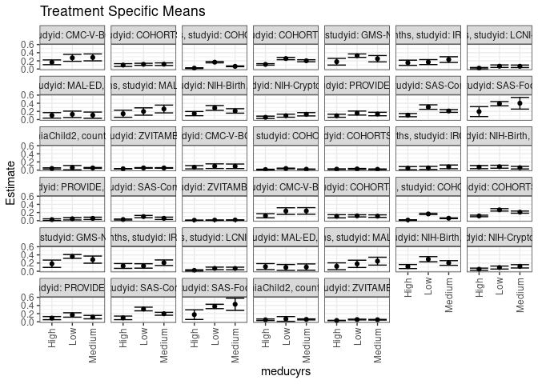

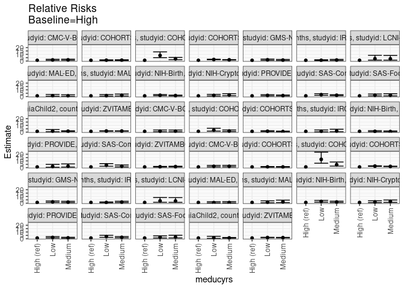

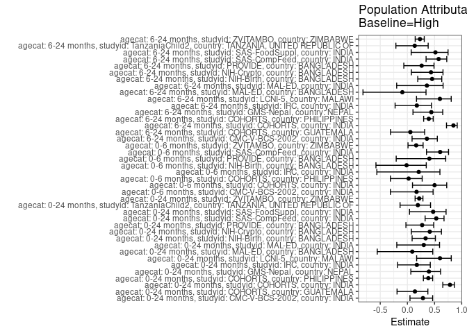

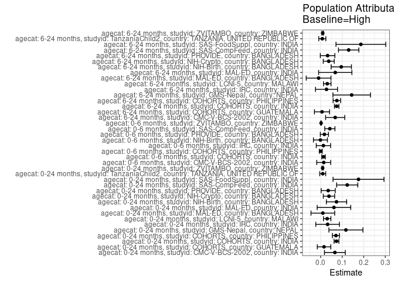

## Results Table

### Parameter: TSM

| agecat | studyid | country | intervention_level | baseline_level | estimate | ci_lower | ci_upper |
| --- | --- | --- | --- | --- | --- | --- | --- |
| 0-24 months | CMC-V-BCS-2002 | INDIA | High | NA | 0.1645570 | 0.1066649 | 0.2224490 |
| 0-24 months | CMC-V-BCS-2002 | INDIA | Low | NA | 0.2735849 | 0.1886049 | 0.3585649 |
| 0-24 months | CMC-V-BCS-2002 | INDIA | Medium | NA | 0.2844037 | 0.1995991 | 0.3692083 |
| 0-24 months | COHORTS | GUATEMALA | High | NA | 0.0964286 | 0.0618412 | 0.1310159 |
| 0-24 months | COHORTS | GUATEMALA | Low | NA | 0.1148325 | 0.0898680 | 0.1397971 |
| 0-24 months | COHORTS | GUATEMALA | Medium | NA | 0.1180723 | 0.0870139 | 0.1491307 |
| 0-24 months | COHORTS | INDIA | High | NA | 0.0202020 | 0.0104029 | 0.0300012 |
| 0-24 months | COHORTS | INDIA | Low | NA | 0.1676923 | 0.1511092 | 0.1842754 |
| 0-24 months | COHORTS | INDIA | Medium | NA | 0.0655050 | 0.0567934 | 0.0742166 |
| 0-24 months | COHORTS | PHILIPPINES | High | NA | 0.1130137 | 0.0948534 | 0.1311740 |
| 0-24 months | COHORTS | PHILIPPINES | Low | NA | 0.2563818 | 0.2278667 | 0.2848969 |
| 0-24 months | COHORTS | PHILIPPINES | Medium | NA | 0.2018443 | 0.1766590 | 0.2270295 |
| 0-24 months | GMS-Nepal | NEPAL | High | NA | 0.1785714 | 0.0966085 | 0.2605344 |
| 0-24 months | GMS-Nepal | NEPAL | Low | NA | 0.3270833 | 0.2850827 | 0.3690839 |
| 0-24 months | GMS-Nepal | NEPAL | Medium | NA | 0.2521008 | 0.1740277 | 0.3301739 |
| 0-24 months | IRC | INDIA | High | NA | 0.1532258 | 0.0897487 | 0.2167029 |
| 0-24 months | IRC | INDIA | Low | NA | 0.1700680 | 0.1092612 | 0.2308748 |
| 0-24 months | IRC | INDIA | Medium | NA | 0.2302158 | 0.1601473 | 0.3002844 |
| 0-24 months | LCNI-5 | MALAWI | High | NA | 0.0201342 | 0.0041770 | 0.0360915 |
| 0-24 months | LCNI-5 | MALAWI | Low | NA | 0.0689655 | 0.0382050 | 0.0997260 |
| 0-24 months | LCNI-5 | MALAWI | Medium | NA | 0.0666667 | 0.0360317 | 0.0973017 |
| 0-24 months | MAL-ED | BANGLADESH | High | NA | 0.1025641 | 0.0350768 | 0.1700514 |
| 0-24 months | MAL-ED | BANGLADESH | Low | NA | 0.1285714 | 0.0499739 | 0.2071690 |
| 0-24 months | MAL-ED | BANGLADESH | Medium | NA | 0.1076923 | 0.0321547 | 0.1832299 |
| 0-24 months | MAL-ED | INDIA | High | NA | 0.1428571 | 0.0562518 | 0.2294625 |
| 0-24 months | MAL-ED | INDIA | Low | NA | 0.1973684 | 0.1076818 | 0.2870550 |
| 0-24 months | MAL-ED | INDIA | Medium | NA | 0.2592593 | 0.1636070 | 0.3549115 |
| 0-24 months | NIH-Birth | BANGLADESH | High | NA | 0.1460674 | 0.0941426 | 0.1979922 |
| 0-24 months | NIH-Birth | BANGLADESH | Low | NA | 0.2850877 | 0.2264409 | 0.3437346 |
| 0-24 months | NIH-Birth | BANGLADESH | Medium | NA | 0.2110092 | 0.1568023 | 0.2652161 |

[output cut: 90 more lines]

### Parameter: E(Y)

| agecat | studyid | country | intervention_level | baseline_level | estimate | ci_lower | ci_upper |
| --- | --- | --- | --- | --- | --- | --- | --- |
| 0-24 months | CMC-V-BCS-2002 | INDIA | NA | NA | 0.2305630 | 0.1877616 | 0.2733644 |
| 0-24 months | COHORTS | GUATEMALA | NA | NA | 0.1119516 | 0.0949484 | 0.1289548 |
| 0-24 months | COHORTS | INDIA | NA | NA | 0.0934771 | 0.0860112 | 0.1009431 |
| 0-24 months | COHORTS | PHILIPPINES | NA | NA | 0.1839080 | 0.1701456 | 0.1976705 |
| 0-24 months | GMS-Nepal | NEPAL | NA | NA | 0.2957540 | 0.2615022 | 0.3300058 |
| 0-24 months | IRC | INDIA | NA | NA | 0.1853659 | 0.1477057 | 0.2230261 |
| 0-24 months | LCNI-5 | MALAWI | NA | NA | 0.0503686 | 0.0353351 | 0.0654020 |
| 0-24 months | MAL-ED | BANGLADESH | NA | NA | 0.1126761 | 0.0701126 | 0.1552395 |
| 0-24 months | MAL-ED | INDIA | NA | NA | 0.2045455 | 0.1511224 | 0.2579685 |
| 0-24 months | NIH-Birth | BANGLADESH | NA | NA | 0.2195513 | 0.1870467 | 0.2520558 |
| 0-24 months | NIH-Crypto | BANGLADESH | NA | NA | 0.0936675 | 0.0729118 | 0.1144233 |
| 0-24 months | PROVIDE | BANGLADESH | NA | NA | 0.1285714 | 0.1037574 | 0.1533855 |
| 0-24 months | SAS-CompFeed | INDIA | NA | NA | 0.2319894 | 0.1917264 | 0.2722524 |
| 0-24 months | SAS-FoodSuppl | INDIA | NA | NA | 0.3708134 | 0.3244530 | 0.4171738 |
| 0-24 months | TanzaniaChild2 | TANZANIA, UNITED REPUBLIC OF | NA | NA | 0.0498743 | 0.0411379 | 0.0586107 |
| 0-24 months | ZVITAMBO | ZIMBABWE | NA | NA | 0.0424508 | 0.0391016 | 0.0458000 |
| 0-6 months | CMC-V-BCS-2002 | INDIA | NA | NA | 0.0842391 | 0.0558231 | 0.1126551 |
| 0-6 months | COHORTS | INDIA | NA | NA | 0.0266667 | 0.0224561 | 0.0308772 |
| 0-6 months | COHORTS | PHILIPPINES | NA | NA | 0.0236531 | 0.0182537 | 0.0290525 |
| 0-6 months | IRC | INDIA | NA | NA | 0.0611247 | 0.0378797 | 0.0843697 |
| 0-6 months | NIH-Birth | BANGLADESH | NA | NA | 0.0723473 | 0.0519719 | 0.0927227 |
| 0-6 months | PROVIDE | BANGLADESH | NA | NA | 0.0428571 | 0.0278427 | 0.0578716 |
| 0-6 months | SAS-CompFeed | INDIA | NA | NA | 0.0704787 | 0.0478990 | 0.0930584 |
| 0-6 months | ZVITAMBO | ZIMBABWE | NA | NA | 0.0120787 | 0.0102578 | 0.0138996 |
| 6-24 months | CMC-V-BCS-2002 | INDIA | NA | NA | 0.1876676 | 0.1479906 | 0.2273445 |
| 6-24 months | COHORTS | GUATEMALA | NA | NA | 0.1136174 | 0.0956322 | 0.1316026 |
| 6-24 months | COHORTS | INDIA | NA | NA | 0.0876552 | 0.0801645 | 0.0951460 |
| 6-24 months | COHORTS | PHILIPPINES | NA | NA | 0.1908832 | 0.1763448 | 0.2054216 |
| 6-24 months | GMS-Nepal | NEPAL | NA | NA | 0.3270869 | 0.2891020 | 0.3650717 |
| 6-24 months | IRC | INDIA | NA | NA | 0.1560976 | 0.1209228 | 0.1912723 |
| 6-24 months | LCNI-5 | MALAWI | NA | NA | 0.0510585 | 0.0358245 | 0.0662926 |
| 6-24 months | MAL-ED | BANGLADESH | NA | NA | 0.1030928 | 0.0601928 | 0.1459928 |
| 6-24 months | MAL-ED | INDIA | NA | NA | 0.1884058 | 0.1350070 | 0.2418045 |
| 6-24 months | NIH-Birth | BANGLADESH | NA | NA | 0.2103321 | 0.1759902 | 0.2446740 |
| 6-24 months | NIH-Crypto | BANGLADESH | NA | NA | 0.0863014 | 0.0659171 | 0.1066856 |
| 6-24 months | PROVIDE | BANGLADESH | NA | NA | 0.1221498 | 0.0962275 | 0.1480722 |
| 6-24 months | SAS-CompFeed | INDIA | NA | NA | 0.2260619 | 0.1909133 | 0.2612105 |
| 6-24 months | SAS-FoodSuppl | INDIA | NA | NA | 0.3615960 | 0.3145115 | 0.4086805 |
| 6-24 months | TanzaniaChild2 | TANZANIA, UNITED REPUBLIC OF | NA | NA | 0.0562189 | 0.0461465 | 0.0662914 |
| 6-24 months | ZVITAMBO | ZIMBABWE | NA | NA | 0.0411187 | 0.0373733 | 0.0448641 |

### Parameter: RR

| agecat | studyid | country | intervention_level | baseline_level | estimate | ci_lower | ci_upper |
| --- | --- | --- | --- | --- | --- | --- | --- |
| 0-24 months | CMC-V-BCS-2002 | INDIA | High | High | 1.0000000 | 1.0000000 | 1.000000 |
| 0-24 months | CMC-V-BCS-2002 | INDIA | Low | High | 1.6625544 | 1.0398198 | 2.658237 |
| 0-24 months | CMC-V-BCS-2002 | INDIA | Medium | High | 1.7282992 | 1.0897676 | 2.740968 |
| 0-24 months | COHORTS | GUATEMALA | High | High | 1.0000000 | 1.0000000 | 1.000000 |
| 0-24 months | COHORTS | GUATEMALA | Low | High | 1.1908559 | 0.7828987 | 1.811394 |
| 0-24 months | COHORTS | GUATEMALA | Medium | High | 1.2244534 | 0.7848164 | 1.910365 |
| 0-24 months | COHORTS | INDIA | High | High | 1.0000000 | 1.0000000 | 1.000000 |
| 0-24 months | COHORTS | INDIA | Low | High | 8.3007692 | 5.0597265 | 13.617884 |
| 0-24 months | COHORTS | INDIA | Medium | High | 3.2424976 | 1.9608629 | 5.361818 |
| 0-24 months | COHORTS | PHILIPPINES | High | High | 1.0000000 | 1.0000000 | 1.000000 |
| 0-24 months | COHORTS | PHILIPPINES | Low | High | 2.2685905 | 1.8658779 | 2.758221 |
| 0-24 months | COHORTS | PHILIPPINES | Medium | High | 1.7860159 | 1.4572350 | 2.188976 |
| 0-24 months | GMS-Nepal | NEPAL | High | High | 1.0000000 | 1.0000000 | 1.000000 |
| 0-24 months | GMS-Nepal | NEPAL | Low | High | 1.8316667 | 1.1372466 | 2.950110 |
| 0-24 months | GMS-Nepal | NEPAL | Medium | High | 1.4117647 | 0.8115105 | 2.456012 |
| 0-24 months | IRC | INDIA | High | High | 1.0000000 | 1.0000000 | 1.000000 |
| 0-24 months | IRC | INDIA | Low | High | 1.1099177 | 0.6421441 | 1.918444 |
| 0-24 months | IRC | INDIA | Medium | High | 1.5024612 | 0.8985670 | 2.512211 |
| 0-24 months | LCNI-5 | MALAWI | High | High | 1.0000000 | 1.0000000 | 1.000000 |
| 0-24 months | LCNI-5 | MALAWI | Low | High | 3.4252874 | 1.3795460 | 8.504677 |
| 0-24 months | LCNI-5 | MALAWI | Medium | High | 3.3111111 | 1.3246625 | 8.276415 |
| 0-24 months | MAL-ED | BANGLADESH | High | High | 1.0000000 | 1.0000000 | 1.000000 |
| 0-24 months | MAL-ED | BANGLADESH | Low | High | 1.2535714 | 0.5106086 | 3.077585 |
| 0-24 months | MAL-ED | BANGLADESH | Medium | High | 1.0500000 | 0.4013361 | 2.747074 |
| 0-24 months | MAL-ED | INDIA | High | High | 1.0000000 | 1.0000000 | 1.000000 |
| 0-24 months | MAL-ED | INDIA | Low | High | 1.3815789 | 0.6476465 | 2.947226 |
| 0-24 months | MAL-ED | INDIA | Medium | High | 1.8148148 | 0.8925300 | 3.690131 |
| 0-24 months | NIH-Birth | BANGLADESH | High | High | 1.0000000 | 1.0000000 | 1.000000 |
| 0-24 months | NIH-Birth | BANGLADESH | Low | High | 1.9517544 | 1.2943540 | 2.943047 |
| 0-24 months | NIH-Birth | BANGLADESH | Medium | High | 1.4446013 | 0.9316855 | 2.239890 |

[output cut: 90 more lines]

### Parameter: PAR

| agecat | studyid | country | intervention_level | baseline_level | estimate | ci_lower | ci_upper |
| --- | --- | --- | --- | --- | --- | --- | --- |
| 0-24 months | CMC-V-BCS-2002 | INDIA | High | NA | 0.0660060 | 0.0175899 | 0.1144221 |
| 0-24 months | COHORTS | GUATEMALA | High | NA | 0.0155230 | -0.0157603 | 0.0468063 |
| 0-24 months | COHORTS | INDIA | High | NA | 0.0732751 | 0.0620625 | 0.0844878 |
| 0-24 months | COHORTS | PHILIPPINES | High | NA | 0.0708943 | 0.0545789 | 0.0872098 |
| 0-24 months | GMS-Nepal | NEPAL | High | NA | 0.1171826 | 0.0381973 | 0.1961679 |
| 0-24 months | IRC | INDIA | High | NA | 0.0321400 | -0.0227268 | 0.0870069 |
| 0-24 months | LCNI-5 | MALAWI | High | NA | 0.0302343 | 0.0130821 | 0.0473866 |
| 0-24 months | MAL-ED | BANGLADESH | High | NA | 0.0101120 | -0.0449377 | 0.0651616 |
| 0-24 months | MAL-ED | INDIA | High | NA | 0.0616883 | -0.0161498 | 0.1395264 |
| 0-24 months | NIH-Birth | BANGLADESH | High | NA | 0.0734839 | 0.0264251 | 0.1205426 |
| 0-24 months | NIH-Crypto | BANGLADESH | High | NA | 0.0385494 | 0.0122640 | 0.0648349 |
| 0-24 months | PROVIDE | BANGLADESH | High | NA | 0.0349544 | 0.0022109 | 0.0676979 |
| 0-24 months | SAS-CompFeed | INDIA | High | NA | 0.1232938 | 0.0741355 | 0.1724520 |
| 0-24 months | SAS-FoodSuppl | INDIA | High | NA | 0.1756914 | 0.0573459 | 0.2940370 |
| 0-24 months | TanzaniaChild2 | TANZANIA, UNITED REPUBLIC OF | High | NA | 0.0096166 | -0.0042025 | 0.0234357 |
| 0-24 months | ZVITAMBO | ZIMBABWE | High | NA | 0.0092234 | 0.0060889 | 0.0123579 |
| 0-6 months | CMC-V-BCS-2002 | INDIA | High | NA | 0.0141754 | -0.0181052 | 0.0464561 |
| 0-6 months | COHORTS | INDIA | High | NA | 0.0133333 | 0.0051388 | 0.0215279 |
| 0-6 months | COHORTS | PHILIPPINES | High | NA | 0.0005366 | -0.0062776 | 0.0073509 |
| 0-6 months | IRC | INDIA | High | NA | 0.0127376 | -0.0204773 | 0.0459525 |
| 0-6 months | NIH-Birth | BANGLADESH | High | NA | -0.0010991 | -0.0335421 | 0.0313440 |
| 0-6 months | PROVIDE | BANGLADESH | High | NA | 0.0173252 | -0.0016288 | 0.0362793 |
| 0-6 months | SAS-CompFeed | INDIA | High | NA | 0.0425284 | 0.0188020 | 0.0662548 |
| 0-6 months | ZVITAMBO | ZIMBABWE | High | NA | 0.0019508 | 0.0002546 | 0.0036469 |
| 6-24 months | CMC-V-BCS-2002 | INDIA | High | NA | 0.0674144 | 0.0230480 | 0.1117808 |
| 6-24 months | COHORTS | GUATEMALA | High | NA | 0.0061794 | -0.0289055 | 0.0412642 |
| 6-24 months | COHORTS | INDIA | High | NA | 0.0743041 | 0.0640474 | 0.0845608 |
| 6-24 months | COHORTS | PHILIPPINES | High | NA | 0.0751337 | 0.0576869 | 0.0925805 |
| 6-24 months | GMS-Nepal | NEPAL | High | NA | 0.1439883 | 0.0568774 | 0.2310992 |
| 6-24 months | IRC | INDIA | High | NA | 0.0270653 | -0.0240842 | 0.0782148 |
| 6-24 months | LCNI-5 | MALAWI | High | NA | 0.0305807 | 0.0131672 | 0.0479943 |
| 6-24 months | MAL-ED | BANGLADESH | High | NA | -0.0095833 | -0.0670104 | 0.0478438 |
| 6-24 months | MAL-ED | INDIA | High | NA | 0.0677161 | -0.0094614 | 0.1448937 |
| 6-24 months | NIH-Birth | BANGLADESH | High | NA | 0.0956824 | 0.0485012 | 0.1428636 |
| 6-24 months | NIH-Crypto | BANGLADESH | High | NA | 0.0375209 | 0.0119851 | 0.0630566 |
| 6-24 months | PROVIDE | BANGLADESH | High | NA | 0.0321024 | -0.0016498 | 0.0658547 |
| 6-24 months | SAS-CompFeed | INDIA | High | NA | 0.1300354 | 0.0828685 | 0.1772023 |
| 6-24 months | SAS-FoodSuppl | INDIA | High | NA | 0.1865960 | 0.0710805 | 0.3021115 |
| 6-24 months | TanzaniaChild2 | TANZANIA, UNITED REPUBLIC OF | High | NA | 0.0075808 | -0.0088659 | 0.0240275 |
| 6-24 months | ZVITAMBO | ZIMBABWE | High | NA | 0.0095199 | 0.0059925 | 0.0130473 |

### Parameter: PAF

| agecat | studyid | country | intervention_level | baseline_level | estimate | ci_lower | ci_upper |
| --- | --- | --- | --- | --- | --- | --- | --- |
| 0-24 months | CMC-V-BCS-2002 | INDIA | High | NA | 0.2862820 | 0.0473322 | 0.4652980 |
| 0-24 months | COHORTS | GUATEMALA | High | NA | 0.1386583 | -0.1905718 | 0.3768460 |
| 0-24 months | COHORTS | INDIA | High | NA | 0.7838828 | 0.6516600 | 0.8659165 |
| 0-24 months | COHORTS | PHILIPPINES | High | NA | 0.3854880 | 0.2940337 | 0.4650949 |
| 0-24 months | GMS-Nepal | NEPAL | High | NA | 0.3962164 | 0.0633555 | 0.6107865 |
| 0-24 months | IRC | INDIA | High | NA | 0.1733871 | -0.1806609 | 0.4212657 |
| 0-24 months | LCNI-5 | MALAWI | High | NA | 0.6002619 | 0.1702459 | 0.8074242 |
| 0-24 months | MAL-ED | BANGLADESH | High | NA | 0.0897436 | -0.5553666 | 0.4672852 |
| 0-24 months | MAL-ED | INDIA | High | NA | 0.3015873 | -0.1952913 | 0.5919151 |
| 0-24 months | NIH-Birth | BANGLADESH | High | NA | 0.3347002 | 0.0867805 | 0.5153150 |
| 0-24 months | NIH-Crypto | BANGLADESH | High | NA | 0.4115559 | 0.0732192 | 0.6263772 |
| 0-24 months | PROVIDE | BANGLADESH | High | NA | 0.2718676 | -0.0269672 | 0.4837452 |
| 0-24 months | SAS-CompFeed | INDIA | High | NA | 0.5314629 | 0.3260023 | 0.6742912 |
| 0-24 months | SAS-FoodSuppl | INDIA | High | NA | 0.4738002 | 0.0387627 | 0.7119481 |
| 0-24 months | TanzaniaChild2 | TANZANIA, UNITED REPUBLIC OF | High | NA | 0.1928172 | -0.1350977 | 0.4260018 |
| 0-24 months | ZVITAMBO | ZIMBABWE | High | NA | 0.2172720 | 0.1418968 | 0.2860262 |
| 0-6 months | CMC-V-BCS-2002 | INDIA | High | NA | 0.1682761 | -0.3128183 | 0.4730691 |
| 0-6 months | COHORTS | INDIA | High | NA | 0.5000000 | 0.0939020 | 0.7240917 |
| 0-6 months | COHORTS | PHILIPPINES | High | NA | 0.0226884 | -0.3123014 | 0.2721656 |
| 0-6 months | IRC | INDIA | High | NA | 0.2083871 | -0.5623325 | 0.5989004 |
| 0-6 months | NIH-Birth | BANGLADESH | High | NA | -0.0151915 | -0.5789884 | 0.3472950 |
| 0-6 months | PROVIDE | BANGLADESH | High | NA | 0.4042553 | -0.2061957 | 0.7057594 |
| 0-6 months | SAS-CompFeed | INDIA | High | NA | 0.6034220 | 0.3516107 | 0.7574388 |
| 0-6 months | ZVITAMBO | ZIMBABWE | High | NA | 0.1615043 | 0.0110962 | 0.2890359 |
| 6-24 months | CMC-V-BCS-2002 | INDIA | High | NA | 0.3592224 | 0.0858727 | 0.5508329 |
| 6-24 months | COHORTS | GUATEMALA | High | NA | 0.0543875 | -0.3106722 | 0.3177676 |
| 6-24 months | COHORTS | INDIA | High | NA | 0.8476858 | 0.7200224 | 0.9171376 |
| 6-24 months | COHORTS | PHILIPPINES | High | NA | 0.3936107 | 0.2991124 | 0.4753681 |
| 6-24 months | GMS-Nepal | NEPAL | High | NA | 0.4402142 | 0.1027794 | 0.6507435 |
| 6-24 months | IRC | INDIA | High | NA | 0.1733871 | -0.2263332 | 0.4428195 |
| 6-24 months | LCNI-5 | MALAWI | High | NA | 0.5989345 | 0.1676110 | 0.8067568 |
| 6-24 months | MAL-ED | BANGLADESH | High | NA | -0.0929577 | -0.8178096 | 0.3428593 |
| 6-24 months | MAL-ED | INDIA | High | NA | 0.3594164 | -0.1972763 | 0.6572660 |
| 6-24 months | NIH-Birth | BANGLADESH | High | NA | 0.4549112 | 0.1907233 | 0.6328551 |
| 6-24 months | NIH-Crypto | BANGLADESH | High | NA | 0.4347658 | 0.0731775 | 0.6552849 |
| 6-24 months | PROVIDE | BANGLADESH | High | NA | 0.2628120 | -0.0658751 | 0.4901409 |
| 6-24 months | SAS-CompFeed | INDIA | High | NA | 0.5752204 | 0.3439714 | 0.7249545 |
| 6-24 months | SAS-FoodSuppl | INDIA | High | NA | 0.5160345 | 0.0697324 | 0.7482202 |
| 6-24 months | TanzaniaChild2 | TANZANIA, UNITED REPUBLIC OF | High | NA | 0.1348438 | -0.2119889 | 0.3824240 |
| 6-24 months | ZVITAMBO | ZIMBABWE | High | NA | 0.2315221 | 0.1435071 | 0.3104925 |